# Transformations of Continuous Random Variables

Brandon Parmanand

2022-07-27

## Take your data set from the first assignment of our course. Find a numeric column that interests you.

```r
setwd("C:/Users/brand/OneDrive/Documents/GitHub/Prob&Stats")
getwd()
```

```
## [1] "C:/Users/brand/OneDrive/Documents/GitHub/Prob&Stats"
```

```r
movies.df <- read.csv("movies.csv")
movies.df <- na.omit(movies.df)
library(car)
```

## Plot a histogram of the column of data. Clearly label your plot with “raw data”.

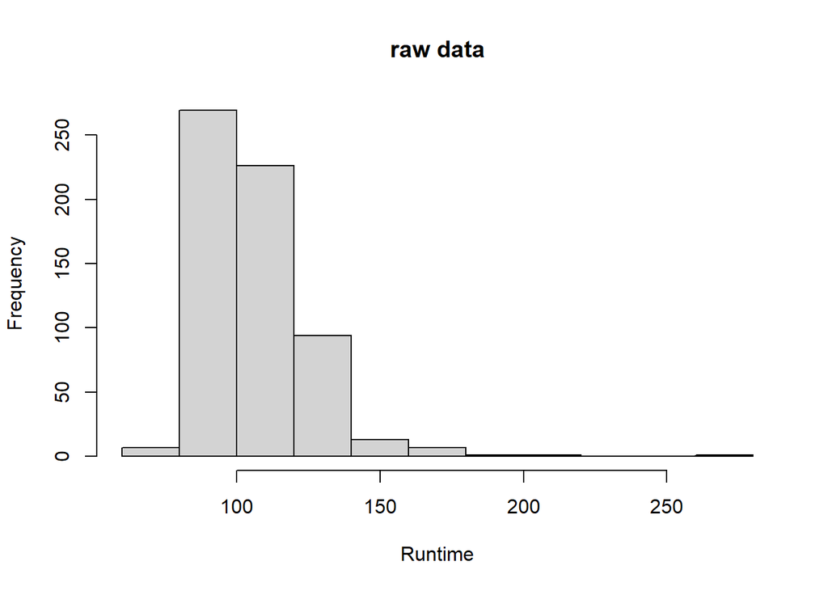

```r
Runtime = movies.df$runtime
hist(x = Runtime, main = "raw data")
```

## Plot a histogram of your data after center and scaling. Clearly label your plot “center and scale”. Comment on how your transformed data is different from your original data.

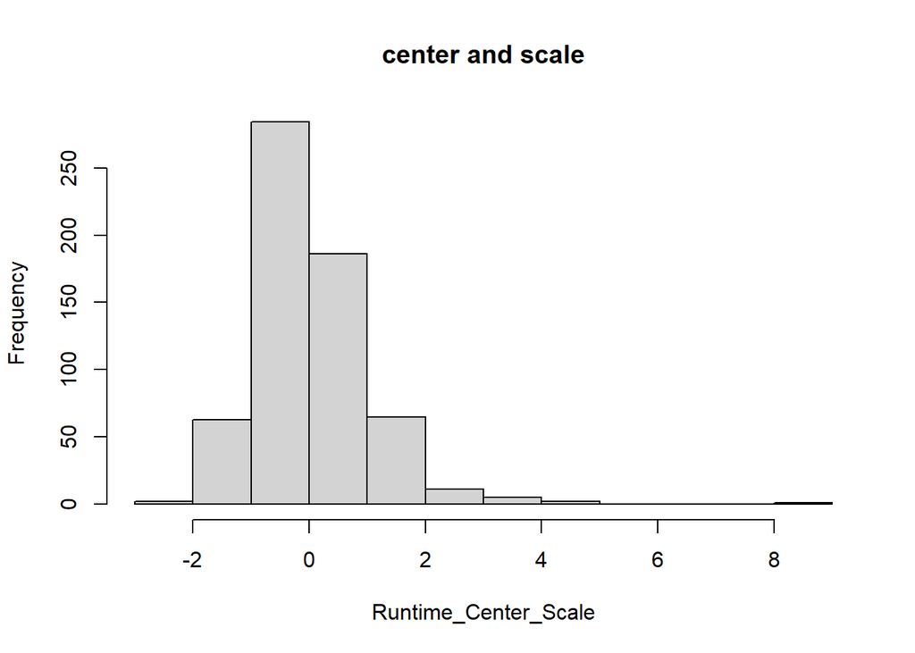

```r
Runtime_Center_Scale = scale(Runtime)
hist(x = Runtime_Center_Scale, main = "center and scale")
```

```r
# Now the data includes negative numbers but it's based around 0 on histogram
```

## Plot a histogram of your data after transforming the range to $[0,1]$. Clearly label your plot “rescale”. Comment on how your transformed data is different from your original data.

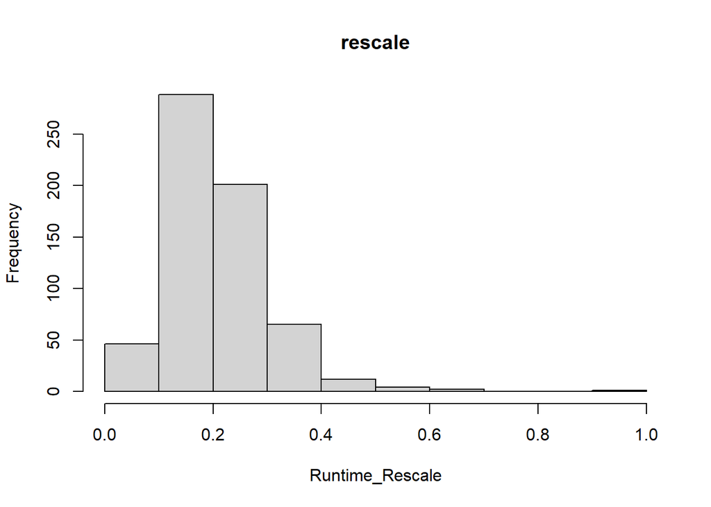

```r
Runtime_Rescale = scales::rescale(Runtime)
hist(x = Runtime_Rescale, main = "rescale")
```

```r
# Looks similar but values are closer to 0 than 1
```

## Plot a histogram of your data after applying a log-transform. Clearly label your plot “log-transform”. If your data has negative or zero values, rescale your data first. Comment on how your transformed data is different from your original data.

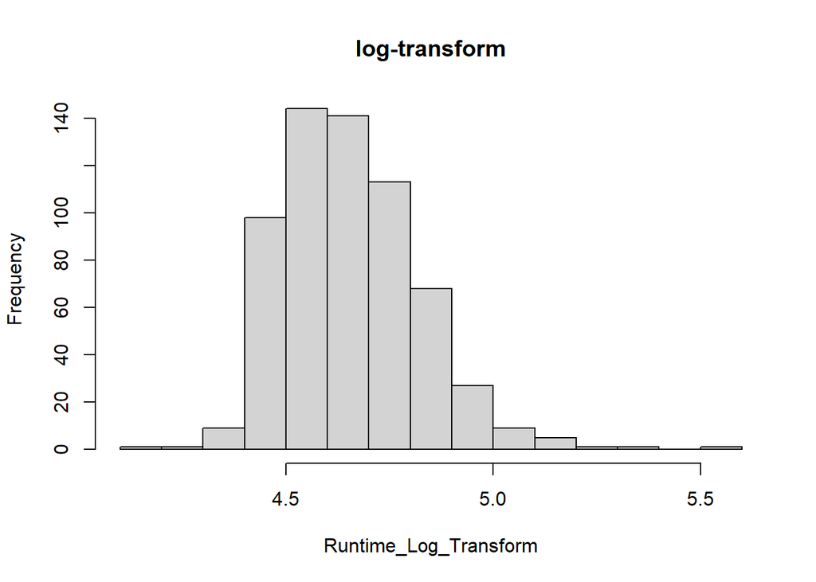

```r
Runtime_Log_Transform = log(Runtime)
hist(x = Runtime_Log_Transform, main = "log-transform")
```

```r
# Histogram looks much more bell shaped than original
```

## Plot a histogram of your data after applying a square-root transform. Clearly label your plot “square-root transform”. If your data has negative values, rescale your data first. Comment on how your transformed data is different from your original data.

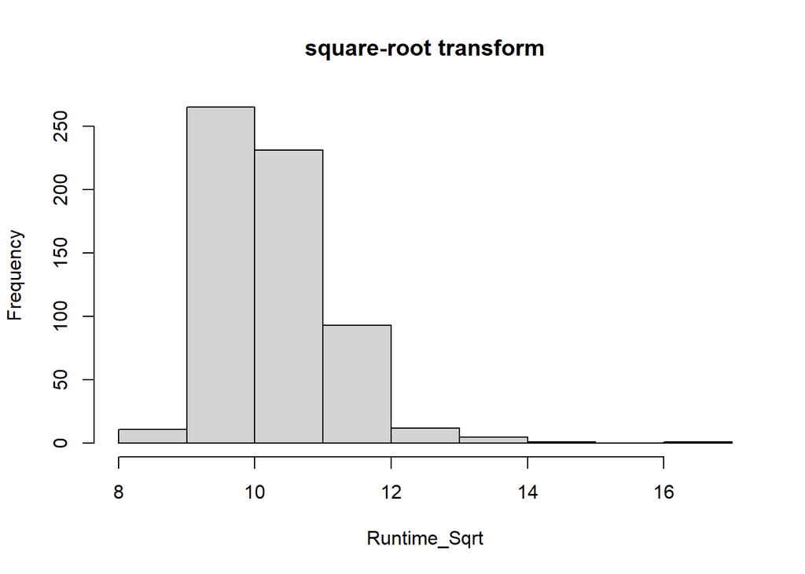

```r
Runtime_Sqrt = sqrt(Runtime)
hist(x = Runtime_Sqrt, main = "square-root transform")
```

```r
# Histogram looks similar to raw data
```

## Plot a histogram of your data after applying a power-transform. Clearly label your plot with the family parameter you used. Comment on how your transformed data is different from your original data.

```r
v <- as.numeric(Runtime)

car::powerTransform(v, family = "bcPower")
```

```
## Estimated transformation parameter
##        v
## -1.39478
```

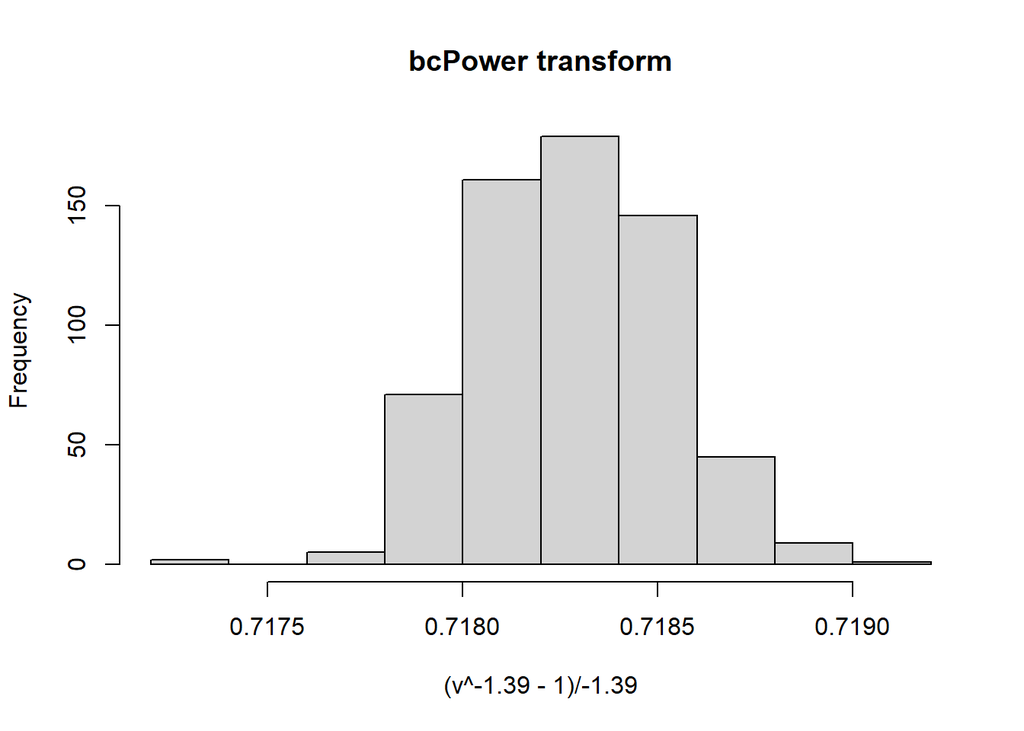

```r
hist((v^-1.39 - 1) / -1.39, main = "bcPower transform")
```

```r
# Histogram is very bell shaped
```